# NLP Basic Movie Review

```python
from nltk.tokenize import sent_tokenize, word_tokenize
```

```python
SAMPLE_TEXT = "This is an example text? Let's see how it works."
```

```python
sent_tokenize(SAMPLE_TEXT)
```

```
['This is an example text?', "Let's see how it works."]
```

```python
words = word_tokenize(SAMPLE_TEXT)
```

```python
from nltk.corpus import stopwords
```

```python
stops = set(stopwords.words('english'))
```

```python
stops
```

```
{'a',
 'about',
 'above',
 'after',
 'again',
 'against',
 'ain',
 'all',
 'am',
 'an',
 'and',
 'any',
 'are',
 'aren',
 'as',
 'at',
 'be',
 'because',
 'been',
 'before',
 'being',
 'below',
 'between',
 'both',
 'but',
 'by',
 'can',
 'couldn',
 'd',
 'did',
 'didn',
 'do',
 'does',
 'doesn',
 'doing',
 'don',
 'down',
 'during',
 'each',
 'few',
```

[output cut: 98 more lines]

```
 'which',
 'while',
 'who',
 'whom',
 'why',
 'will',
 'with',
 'won',
 'wouldn',
 'y',
 'you',
 'your',
 'yours',
 'yourself',
 'yourselves'}
```

```python
lower_text = SAMPLE_TEXT.lower()
lower_text = word_tokenize(lower_text)
```

```python
clean_wrods = [w for w in lower_text if not w in stops]
```

```python
clean_wrods
```

```
['example', 'text', '?', 'let', "'s", 'see', 'works', '.']
```

stem_words

```python
stem_words = ["play", "played", "playing", "player"]
from nltk.stem import  PorterStemmer
ps = PorterStemmer()
for w in stem_words:
    print(ps.stem(w))
```

```
play
play
play
player
```

```python
words = ["imperfect", "perfect"]
ps = PorterStemmer()
for w in words:
    print(ps.stem(w))
```

```
imperfect
perfect
```

```python
from nltk import pos_tag
from nltk.corpus import state_union
```

```python
text = state_union.raw("2006-GWBush.txt")
```

```python
text
```

```
'PRESIDENT GEORGE W. BUSH\'S ADDRESS BEFORE A JOINT SESSION OF THE CONGRESS ON THE STATE OF THE UNION\n \nJanuary 31, 2006\n\nTHE PRESIDENT: Thank you all. Mr. Speaker, Vice President Cheney, members of Congress, members of the Supreme Court and diplomatic corps, distinguished guests, and fellow cit…
```

```python
pos = pos_tag(word_tokenize(text))
```

```python
pos[1:50]
```

```
[('GEORGE', 'NNP'),
 ('W.', 'NNP'),
 ('BUSH', 'NNP'),
 ("'S", 'POS'),
 ('ADDRESS', 'NNP'),
 ('BEFORE', 'IN'),
 ('A', 'NNP'),
 ('JOINT', 'NNP'),
 ('SESSION', 'NNP'),
 ('OF', 'IN'),
 ('THE', 'NNP'),
 ('CONGRESS', 'NNP'),
 ('ON', 'NNP'),
 ('THE', 'NNP'),
 ('STATE', 'NNP'),
 ('OF', 'IN'),
 ('THE', 'NNP'),
 ('UNION', 'NNP'),
 ('January', 'NNP'),
 ('31', 'CD'),
 (',', ','),
 ('2006', 'CD'),
 ('THE', 'NNP'),
 ('PRESIDENT', 'NNP'),
 (':', ':'),
 ('Thank', 'NNP'),
 ('you', 'PRP'),
 ('all', 'DT'),
 ('.', '.'),
 ('Mr.', 'NNP'),
 ('Speaker', 'NNP'),
 (',', ','),
 ('Vice', 'NNP'),
 ('President', 'NNP'),
 ('Cheney', 'NNP'),
 (',', ','),
 ('members', 'NNS'),
 ('of', 'IN'),
 ('Congress', 'NNP'),
 (',', ','),
 ('members', 'NNS'),
 ('of', 'IN'),
 ('the', 'DT'),
 ('Supreme', 'NNP'),
 ('Court', 'NNP'),
 ('and', 'CC'),
 ('diplomatic', 'JJ'),
 ('corps', 'NN'),
 (',', ',')]
```

POS tag list: CC coordinating conjunction CD cardinal digit DT determiner EX existential there (like: "there is" ... think of it like "there exists") FW foreign word IN preposition/subordinating conjunction JJ adjective 'big' JJR adjective, comparative 'bigger' JJS adjective, superlative 'biggest' LS list marker 1) MD modal could, will NN noun, singular 'desk' NNS noun plural 'desks' NNP proper noun, singular 'Harrison' NNPS proper noun, plural 'Americans' PDT predeterminer 'all the kids' POS possessive ending parent's PRP personal pronoun I, he, she PRP$ possessive pronoun my, his, hers RB adverb very, silently, RBR adverb, comparative better RBS adverb, superlative best RP particle give up TO to go 'to' the store. UH interjection errrrrrrrm VB verb, base form take VBD verb, past tense took VBG verb, gerund/present participle taking VBN verb, past participle taken VBP verb, sing. present, non-3d take VBZ verb, 3rd person sing. present takes WDT wh-determiner which WP wh-pronoun who, what WP$ possessive wh-pronoun whose WRB wh-abverb where, when

```python
from nltk.stem import WordNetLemmatizer
```

```python
lemmatizer = WordNetLemmatizer()
```

```python
lemmatizer.lemmatize("good", pos = "a")
```

```
'good'
```

```python
lemmatizer.lemmatize("better", pos = "a")
```

```
'good'
```

```python
lemmatizer.lemmatize("excellent", pos = "n")
```

```
'excellent'
```

```python
lemmatizer.lemmatize("painting", pos = "v")
```

```
'paint'
```

```python
lemmatizer.lemmatize("painting", pos = "n")
```

```
'painting'
```

```python
lemmatizer.lemmatize("studies", pos = "v")
```

```
'study'
```

lemmatizer.lemmatize("studies", pos = "n")

```python
from nltk.corpus import wordnet
```

```python
syns = wordnet.synsets("can")
syns
```

```
[Synset('can.n.01'),
 Synset('can.n.02'),
 Synset('can.n.03'),
 Synset('buttocks.n.01'),
 Synset('toilet.n.02'),
 Synset('toilet.n.01'),
 Synset('can.v.01'),
 Synset('displace.v.03')]
```

```python
syns = wordnet.synsets("regard")
syns
```

```
[Synset('respect.n.01'),
 Synset('attentiveness.n.01'),
 Synset('regard.n.03'),
 Synset('gaze.n.01'),
 Synset('esteem.n.01'),
 Synset('regard.n.06'),
 Synset('respect.n.03'),
 Synset('see.v.05'),
 Synset('regard.v.02'),
 Synset('involve.v.01')]
```

```python
syns[4].definition()
```

```
'the condition of being honored (esteemed or respected or well regarded)'
```

```python
syns[2].examples()
```

```
['give him my kind regards', 'my best wishes']
```

```python
syns[5].examples()
```

```
['she mistook his manly regard for love', 'he inspires respect']
```

```python
w1 = wordnet.synset('boat.n.01')
w2 = wordnet.synset('car.n.01')
print(w1.wup_similarity(w2))
```

```
0.6956521739130435
```

```python
w1 = wordnet.synset('boat.n.01')
w2 = wordnet.synset('ship.n.01')
print(w1.wup_similarity(w2))
```

```
0.9090909090909091
```

```python
from nltk import ne_chunk
```

```python
sentence = "Sergey Brin, the manager of Google Inc. is walking down the street in London."
sentence =  sentence.lower()
```

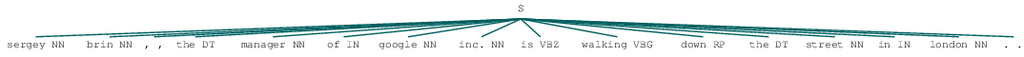

```python
converted = ne_chunk(pos_tag(word_tokenize(sentence)))
converted
```

ORGANIZATION - Georgia-Pacific Corp., WHO PERSON - Eddy Bonte, President Obama LOCATION - Murray River, Mount Everest DATE - June, 2008-06-29 TIME - two fifty a m, 1:30 p.m. MONEY - 175 million Canadian Dollars, GBP 10.40 PERCENT - twenty pct, 18.75 % FACILITY - Washington Monument, Stonehenge GPE - South East Asia, Midlothian

```python
from nltk.corpus import movie_reviews
```

movie_reviews.categories()

```python
movie_reviews.words(movie_reviews.fileids()[5])
```

```
['capsule', ':', 'in', '2176', 'on', 'the', 'planet', ...]
```

```python
documents = []
for category in movie_reviews.categories():
    for fileid in movie_reviews.fileids(category):
        documents.append((movie_reviews.words(fileid), category))
```

```python
len(documents)
```

```
2000
```

```python
documents[2][1]
```

```
'neg'
```

```python
import random
random.shuffle(documents)
```

```python
all_words = []
stops.update(".", "?", "(", ")", ",", "-", "'", '"')
for w in movie_reviews.words():
    if w.lower() not in stops:
        all_words.append(w.lower())
```

```python
len(all_words)
```

```
721009
```

```python
import nltk
```

```python
all_words = nltk.FreqDist(all_words)
all_words.most_common(15)
```

```
[('film', 9517),
 ('one', 5852),
 ('movie', 5771),
 ('like', 3690),
 (':', 3042),
 ('even', 2565),
 ('good', 2411),
 ('time', 2411),
 ('story', 2169),
 ('would', 2109),
 ('much', 2049),
 ('character', 2020),
 ('also', 1967),
 ('get', 1949),
 ('two', 1911)]
```

```python
word_features = list(all_words.most_common(3000)[:,0])
```

[output not shown]

```python
word_features = []
most_common = all_words.most_common()
```

```python
for i in range(3000):
    word_features.append(most_common[i][0])
```

```python
len(word_features)
```

```
3000
```

```python
word_features[1:10]
```

```
['one', 'movie', 'like', ':', 'even', 'good', 'time', 'story', 'would']
```

```python
def find_features(document):
    words = set(document)
    features = {}
    for w in word_features:
        features[w] = (w in words)
    return features
```

```python
features = find_features(movie_reviews.words(movie_reviews.fileids()[2]))
```

```python
featuresets = [(find_features(doc), category) for (doc,category) in documents]
```

```python
featuresets[0]
```

```
({'lisa': False,
  'surely': False,
  'buddies': False,
  'lighting': False,
  'occasionally': False,
  'pleasure': False,
  'introduced': False,
  'journey': False,
  'hip': False,
  'silly': True,
  'holds': False,
  'mountain': False,
  'instance': False,
  '&': False,
  '1999': False,
  'neil': False,
  'ed': False,
  'arrives': False,
  'accident': False,
  'explain': False,
  'suppose': False,
  'command': False,
  'working': False,
  'hands': False,
  'van': False,
  'hearing': False,
  'pure': False,
  'assistant': False,
  'magical': False,
  'status': False,
  'done': False,
  '80s': False,
  'memorable': False,
  'natural': False,
  'rescue': False,
  'fascinating': False,
  'patient': False,
  'points': False,
  'stunts': False,
  'reasons': False,
```

[output cut: 947 more lines]

```
  'critique': False,
  'met': False,
  'rent': False,
  'place': False,
  'excuse': False,
  'creepy': False,
  'okay': False,
  'rarely': False,
  'camera': False,
  'glenn': False,
  'substance': False,
  'arquette': False,
  'great': False,
  ...},
 'pos')
```

```python
training_set = featuresets[:1500]
testing_set = featuresets[1500:]
```

```python
classifier = nltk.NaiveBayesClassifier.train(training_set)
```

```python
nltk.classify.accuracy(classifier, testing_set)
```

```
0.752
```

```python
classifier.show_most_informative_features(15)
```

```
Most Informative Features
                  seagal = True              neg : pos    =     10.8 : 1.0
             outstanding = True              pos : neg    =     10.5 : 1.0
                   anger = True              pos : neg    =      9.7 : 1.0
                   jolie = True              neg : pos    =      8.9 : 1.0
                  prinze = True              neg : pos    =      8.9 : 1.0
              henstridge = True              neg : pos    =      7.5 : 1.0
                 garbage = True              neg : pos    =      7.3 : 1.0
             wonderfully = True              pos : neg    =      7.1 : 1.0
                 idiotic = True              neg : pos    =      6.5 : 1.0
                   mulan = True              pos : neg    =      6.4 : 1.0
                  poorly = True              neg : pos    =      6.3 : 1.0
                   damon = True              pos : neg    =      6.2 : 1.0
               innocence = True              pos : neg    =      6.0 : 1.0
            breathtaking = True              pos : neg    =      6.0 : 1.0
             beautifully = True              pos : neg    =      5.8 : 1.0
```

```python
from nltk.classify.scikitlearn import SklearnClassifier

from sklearn.svm import SVC
```

```python
SVC_classifier = SklearnClassifier(SVC())
SVC_classifier.train(training_set)
nltk.classify.accuracy(SVC_classifier, testing_set)
```

```
0.708
```

```python
import pickle
```

```python
save_classifier = open("naivebayes.pickle", "wb")
pickle.dump(classifier, save_classifier)
save_classifier.close()
```

```python
classifier_new = open("naivebayes.pickle", "rb")
classifier = pickle.load(classifier_new)
classifier_new.close()
```

```python
train_set = ("The sky is blue.", "The sun is bright")
```

```python
from sklearn.feature_extraction.text import CountVectorizer
```

```python
count_vec = CountVectorizer()
```

```python
count_vec.fit_transform(train_set)
```

```
<2x6 sparse matrix of type '<class 'numpy.int64'>'
	with 8 stored elements in Compressed Sparse Row format>
```

```python
count_vec.get_feature_names()
```

```
['blue', 'bright', 'is', 'sky', 'sun', 'the']
```

```python
test_sen = ("The sky is bright and blue", "Bright day")
```

```python
freq_term = count_vec.transform(test_sen)
```

```python
freq_term.todense()
```

```
matrix([[1, 1, 1, 1, 0, 1],
        [0, 1, 0, 0, 0, 0]])
```

```python
reviews = []
categories = []
for (rev, category) in documents:
    reviews.append(rev)
    categories.append(category)
```

```python
from nltk import pos_tag
from nltk.stem import WordNetLemmatizer
from nltk.corpus import wordnet
```

```python
lemmatizer = WordNetLemmatizer()
```

```python
def get_simple_pos(tag):

    if tag.startswith('J'):
        return wordnet.ADJ
    elif tag.startswith('V'):
        return wordnet.VERB
    elif tag.startswith('N'):
        return wordnet.NOUN
    elif tag.startswith('R'):
        return wordnet.ADV
    else:
        return wordnet.NOUN
```

```python
def clean_data(data):
    meaningful_words = []
    for w in data:
        if w.lower() not in stops:
            pos = pos_tag([w])
           # print(pos)
         #  if get_simple_tag(pos)
            n_word = lemmatizer.lemmatize(w, pos = get_simple_pos(pos[0][1]))
            meaningful_words.append(n_word.lower())
    return (" ".join(meaningful_words))
```

```python
clean_review = clean_data(reviews[0])
```

```python
clean_review
```

```
'spent entire life awful little apartment raise care imprison domineer mother inspires love fear instills similar love fear jesus rudimentary grasp language mouth monosyllable repetition mother phrase taught world outside fatally poisonous ; mother don gasmask whenever go door 35 year old body child…
```

```python
clean_reviews = [clean_data(review) for review in reviews]
```

```python
from sklearn.cross_validation import train_test_split
```

```python
x_train, x_test, y_train, y_test = train_test_split(clean_reviews, categories, test_size = 0.2)
```

```python
count_vect = CountVectorizer(analyzer = "word", max_features = 4500)
```

```python
train_transformed = count_vect.fit_transform(x_train)
```

```python
train_transformed.shape
```

```
(1600, 4500)
```

```python
test_transformed = count_vect.transform(x_test)
```